# Fifa_WorldCup_CSV

### Checking the null data of Nationality Column

```python
fifa_data['Nationality'].isnull().sum()
```

```
0
```

```python
from bokeh.io import output_notebook
from bokeh.io import show
from bokeh.plotting import figure
from bokeh.transform import cumsum
from bokeh.palettes import Spectral6
from bokeh.models import ColumnDataSource
from bokeh.layouts import gridplot
```

```python
nationality_counts = fifa_data.groupby('Nationality').size()
```

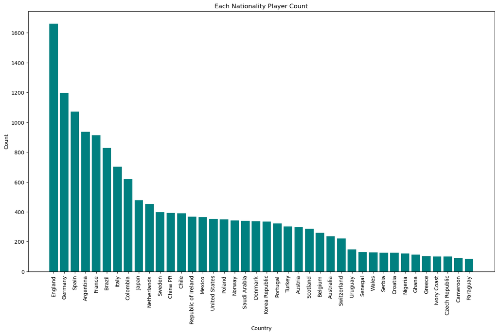

```python
import matplotlib.pyplot as plt

countries = list(fifa_data['Nationality'].value_counts()[:40].index)
count = list(fifa_data['Nationality'].value_counts()[:40].values)

fig, ax = plt.subplots(figsize=(16, 9))

ax.bar(countries, count, color='teal')
ax.set_title('Each Nationality Player Count')
ax.set_xlabel('Country')
ax.set_ylabel('Count')
ax.set_xticklabels(countries, rotation='vertical')

plt.show()
```

### Above is a plot of number of players belonging to top 40 countries. As expected maximum number of players belongs to England, then Germany, and then Spain

[output not shown]

```python
fifa_data.loc[fifa_data['Nationality'] == 'India'].head()
```

|  | ID | Name | Age | Nationality | Overall | Potential | Club | Value | Wage | Preferred Foot | International Reputation | Skill Moves | Position | Joined | Contract Valid Until | Height | Weight | Release Clause |
| --- | --- | --- | --- | --- | --- | --- | --- | --- | --- | --- | --- | --- | --- | --- | --- | --- | --- | --- |
| 8605 | 190939 | S. Chhetri | 33 | India | 67 | 67 | NaN | NaN | 0.0 | Right | 1.0 | 3.0 | LS | 2016 | NaN | 5.583333 | 154.0 | 4585.060806 |
| 10011 | 223763 | S. Jhingan | 24 | India | 65 | 71 | NaN | NaN | 0.0 | Right | 1.0 | 2.0 | RCB | 2016 | NaN | 6.166667 | 163.0 | 4585.060806 |
| 12598 | 217225 | J. Lalpekhlua | 27 | India | 63 | 64 | NaN | NaN | 0.0 | Right | 1.0 | 2.0 | RS | 2016 | NaN | 5.750000 | 165.0 | 4585.060806 |
| 12811 | 225213 | G. Singh Sandhu | 26 | India | 63 | 68 | NaN | NaN | 0.0 | Right | 1.0 | 1.0 | GK | 2016 | NaN | 6.333333 | 198.0 | 4585.060806 |
| 13508 | 238205 | A. Edathodika | 31 | India | 62 | 62 | NaN | NaN | 0.0 | Left | 1.0 | 2.0 | LCB | 2016 | NaN | 6.000000 | 172.0 | 4585.060806 |

### Let's plot the overall score of each Indian Player

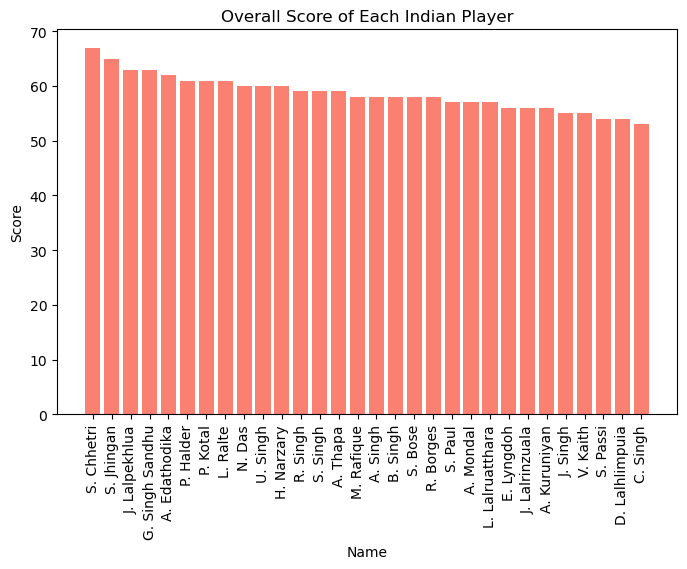

```python
import matplotlib.pyplot as plt

names = fifa_data.loc[fifa_data['Nationality'] == 'India']['Name'].to_list()
score = fifa_data.loc[fifa_data['Nationality'] == 'India']['Overall'].to_list()

fig, ax = plt.subplots(figsize=(8, 5))

ax.bar(names, score, color='salmon')
ax.set_title('Overall Score of Each Indian Player')
ax.set_xlabel('Name')
ax.set_ylabel('Score')
ax.set_xticklabels(names, rotation='vertical')

plt.show()
```

### It seems that all the Indian players have similar overall score (S Chhetri scored top comparing) but the number of Indian players in the list are really less

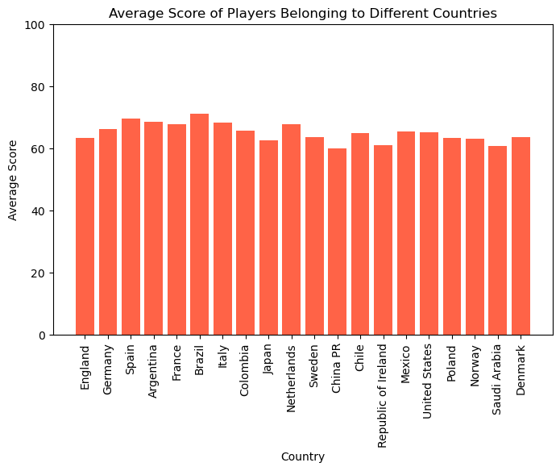

```python
import matplotlib.pyplot as plt
import numpy as np

top_20_countries = fifa_data['Nationality'].value_counts().head(20).index.to_list()
avg_scores = []
for country in top_20_countries:
    avg_score = fifa_data.loc[fifa_data['Nationality'] == country]['Overall'].mean()
    avg_scores.append(avg_score)

fig, ax = plt.subplots(figsize=(8, 5))

ax.bar(top_20_countries, avg_scores, color='tomato')
ax.set_title('Average Score of Players Belonging to Different Countries')
ax.set_xlabel('Country')
ax.set_ylabel('Average Score')
ax.set_xticklabels(top_20_countries, rotation='vertical')
ax.set_ylim([0, 100])

plt.show()
```

### As we can see The highest average of overall score was for Brazil followed by Spain.

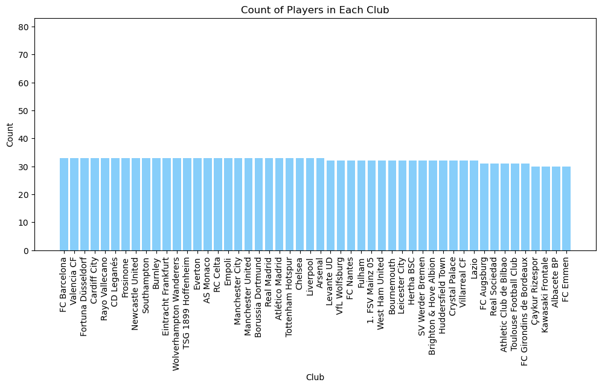

```python
import matplotlib.pyplot as plt

clubs = fifa_data['Club'].value_counts().index.tolist()[:50]
count = fifa_data['Club'].value_counts().tolist()[:50]

fig, ax = plt.subplots(figsize=(12, 5))

ax.bar(clubs, count, color='lightskyblue')
ax.set_title('Count of Players in Each Club')
ax.set_xlabel('Club')
ax.set_ylabel('Count')
ax.set_xticklabels(clubs, rotation='vertical')
ax.set_ylim([0, max(count)+50])

plt.show()
```

### On and average we can say each club is havinng 30-33 players.

### Let's checkout the player who has the highest and the lowest potential , before jumping to that we will check either we have any duplicate data or not

```python
fifa_data['Potential'].isnull().sum()
```

```
0
```

### There are no null values, so we are good to go

```python
fifa_data.loc[fifa_data['Potential'] == fifa_data['Potential'].max()]
```

|  | ID | Name | Age | Nationality | Overall | Potential | Club | Value | Wage | Preferred Foot | International Reputation | Skill Moves | Position | Joined | Contract Valid Until | Height | Weight | Release Clause |
| --- | --- | --- | --- | --- | --- | --- | --- | --- | --- | --- | --- | --- | --- | --- | --- | --- | --- | --- |
| 25 | 231747 | K. Mbappé | 19 | France | 88 | 95 | Paris Saint-Germain | 81000.0 | 100.0 | Right | 3.0 | 5.0 | RM | 2018 | 2022-01-01 | 5.833333 | 161.0 | 166100.0 |

```python
fifa_data.loc[fifa_data['Potential'] == fifa_data['Potential'].min()]
```

|  | ID | Name | Age | Nationality | Overall | Potential | Club | Value | Wage | Preferred Foot | International Reputation | Skill Moves | Position | Joined | Contract Valid Until | Height | Weight | Release Clause |
| --- | --- | --- | --- | --- | --- | --- | --- | --- | --- | --- | --- | --- | --- | --- | --- | --- | --- | --- |
| 18171 | 237746 | Y. Uchimura | 33 | Japan | 48 | 48 | Hokkaido Consadole Sapporo | 20.0 | 1.0 | Right | 1.0 | 2.0 | CAM | 2010 | 2021-01-01 | 5.750000 | 148.0 | 25.000000 |
| 18183 | 53748 | K. Pilkington | 44 | England | 48 | 48 | Cambridge United | NaN | 1.0 | Right | 1.0 | 1.0 | GK | 2018 | 2023-01-01 | 6.166667 | 190.0 | 4585.060806 |

### K. Mbappe has a potential score of 95 which is amazing, he truely deserves it

### We can observe that the high potential player ,K. Mbappe is highly paid and his overall score is also very high